# Contingency Tables

To obtain information from the General Social Survey, go to sda.berkley.edu. Click the ARCHIVE button. In what follows, we will use information obtained from the [General Social Survey (GSS) Cumulative Datafile 1972-2010](http://sda.berkeley.edu/cgi-bin/hsda?harcsda+gss10). The following data file is obtained by clicking Download > Customized Subset. Click in the radio button to the left of CSV file (Comma Separated Values with header record). Enter `age(18-65)` in the Selection Filter(s) box. Type `DEATHPEN SEX` in the Enter names of individual variables (original or created) to include box. Scroll to the bottom of the page, and click the Continue button. Review the page that appears to make sure you have selected the desired variables; then, click the `Create the Files` button. You should have two hot links: the `Data file` and the `Codebook`. By clicking on the `Data file` link, the information should open in your browser. To read the data into `R`, copy the url and store it as follows. Note the url `site` is temporary. Consequently, we download the data to a folder on the hard drive. The initial code is commented out as the url will no longer work after a day or so. That is, you will need to get a new url if you want to duplicate the entire process.

```r
# site <- "http://sda.berkeley.edu/TMPDIR/AAELN0Q9.csv"
# download.file(url = site, destfile = "../data/DPS.csv")
DPS <- read.csv(file="../data/DPS.csv")
xtabs(~SEX + DEATHPEN, data = DPS)
```

```
   DEATHPEN
SEX     0     1     2     3     4     5     8     9
  1 20263   257   103    28    37    35    11     0
  2 24601   283   160    58    67    37    32     2
```

Based on the `Codebook`, values 0, 8, and 9 are missing data values for the variable DEATHPEN. We would like to store those values in our data frame as NA’s (how `R` stores missing data). Further, it would be nice to label the various categories according to their labels versus their numerical values. To map character values to the numerical entries, we will use the `plyr` package (it can also be done using straight `R` commands).

```r
DPS$DEATHPEN <- plyr::mapvalues(DPS$DEATHPEN, from = c(0,1,2,3,4,5,8,9), to =c(NA, "Strongly Agree", "Agree", "Neither Agree nor Disagree", "Disagree", "Strongly Disagree", NA, NA))
DPS$SEX <- plyr::mapvalues(DPS$SEX, from =c(1, 2), to = c("Male", "Female"))
xtabs(~SEX + DEATHPEN, data = DPS)
```

```
##         DEATHPEN
## SEX      Agree Disagree Neither Agree nor Disagree Strongly Agree
##   Female   160       67                         58            283
##   Male     103       37                         28            257
##         DEATHPEN
## SEX      Strongly Disagree
##   Female                37
##   Male                  35
```

The problem with the latest table is that the labels for the values appear in alphabetical order. To solve this problem, we convert the character variables, `SEX` and `DEATHPEN` to factors and assign the order of the levels using the `levels=` command.

```r
DPS$DEATHPEN <- factor(DPS$DEATHPEN, levels = c("Strongly Agree", "Agree", "Neither Agree nor Disagree", "Disagree", "Strongly Disagree"))
DPS$SEX <- factor(DPS$SEX, levels = c("Male", "Female"))
T1 <- xtabs(~SEX + DEATHPEN, data = DPS)
T1
```

```
##         DEATHPEN
## SEX      Strongly Agree Agree Neither Agree nor Disagree Disagree
##   Male              257   103                         28       37
##   Female            283   160                         58       67
##         DEATHPEN
## SEX      Strongly Disagree
##   Male                  35
##   Female                37
```

```r
addmargins(T1)
```

```
##         DEATHPEN
## SEX      Strongly Agree Agree Neither Agree nor Disagree Disagree
##   Male              257   103                         28       37
##   Female            283   160                         58       67
##   Sum               540   263                         86      104
##         DEATHPEN
## SEX      Strongly Disagree  Sum
##   Male                  35  460
##   Female                37  605
##   Sum                   72 1065
```

```r
prop.table(T1, 1)
```

```
##         DEATHPEN
## SEX      Strongly Agree      Agree Neither Agree nor Disagree   Disagree
##   Male       0.55869565 0.22391304                 0.06086957 0.08043478
##   Female     0.46776860 0.26446281                 0.09586777 0.11074380
##         DEATHPEN
## SEX      Strongly Disagree
##   Male          0.07608696
##   Female        0.06115702
```

# Test for Independence

If SEX and DEATHPEN are independent, the expected count $E_{ij}$ for any cell is the row total times the column proportion, which is equivalent to the column total times the row proportion:
$$E_{ij} = R_i(C_j/n) = C_j(R_i/n) = R_iC_j/n.$$

If SEX and DEATHPEN are independent, then the observed and the expected values for all cells should be similar. The degree of similarity is measured with the statistic
$$\sum_{cells}\dfrac{(OBS - EXP)^2}{EXP}$$

## Null and Alternative Hypotheses

The hypotheses to be tested are written as follows:

$H_0:$ Death penalty opinion is independent of gender (there is no association between death penalty opinion and gender).

$H_A:$ Death penalty opionion is dependent on gender (there is an association between death penalty opinion and gender).

## `R` interlude

Consider how the `outer()` function works, which we will use to compute expected values.

```r
outer(1:3, 1:3)
```

```
##      [,1] [,2] [,3]
## [1,]    1    2    3
## [2,]    2    4    6
## [3,]    3    6    9
```

```r
outer(1:3, 3:1)
```

```
##      [,1] [,2] [,3]
## [1,]    3    2    1
## [2,]    6    4    2
## [3,]    9    6    3
```

```r
outer(1:3, 3:1, "+")
```

```
##      [,1] [,2] [,3]
## [1,]    4    3    2
## [2,]    5    4    3
## [3,]    6    5    4
```

```r
outer(1:3, 3:1, "^")
```

```
##      [,1] [,2] [,3]
## [1,]    1    1    1
## [2,]    8    4    2
## [3,]   27    9    3
```

The expected counts for `T1` are

```r
EC <- function(TAB){
  outer(apply(TAB,1 , sum), apply(TAB, 2, sum))/sum(TAB)
}
EC(T1)
```

```
##        Strongly Agree    Agree Neither Agree nor Disagree Disagree
## Male         233.2394 113.5962                   37.14554 44.92019
## Female       306.7606 149.4038                   48.85446 59.07981
##        Strongly Disagree
## Male            31.09859
## Female          40.90141
```

To remove all of the `NA` values from `DPS`, use `na.omit()` as follows.

```r
str(DPS)
```

```
## 'data.frame':    45974 obs. of  3 variables:
##  $ CASEID  : int  1 3 4 5 6 7 8 9 10 11 ...
##  $ DEATHPEN: Factor w/ 5 levels "Strongly Agree",..: NA NA NA NA NA NA NA NA NA NA ...
##  $ SEX     : Factor w/ 2 levels "Male","Female": 2 2 2 2 1 1 1 2 2 2 ...
```

```r
DPSC <- na.omit(DPS)
str(DPSC)
```

```
## 'data.frame':    1065 obs. of  3 variables:
##  $ CASEID  : int  26266 26267 26268 26270 26271 26272 26274 26275 26278 26279 ...
##  $ DEATHPEN: Factor w/ 5 levels "Strongly Agree",..: 1 1 2 1 2 3 2 1 1 2 ...
##  $ SEX     : Factor w/ 2 levels "Male","Female": 2 2 1 2 1 1 2 2 1 1 ...
##  - attr(*, "na.action")=Class 'omit'  Named int [1:44909] 1 2 3 4 5 6 7 8 9 10 ...
##   .. ..- attr(*, "names")= chr [1:44909] "1" "2" "3" "4" ...
```

Note that `DPSC` has 1065 observations where `DPS` has 45974 observations, but 44909 of the observations in `DPS` are `NA`. To perform a permutation test, we will need to use the cleaned up version of the data frame `DPSC`.

## Permutation Test for Independence

To perform a permutation test for independence between two categorical variables, the data will need to be stored in two columns. For example, if a contingency tables has 1065 entries, that data will need to be stored in an object with 1065 rows and a column for each categorical variable. If the null hypothesis that `SEX` and `DEATHPEN` are independent is correct, then we could permute either the `SEX` or `DEATHPEN` values, and any other permutation would be equally likely. For each permutation resample, we will obtain a contingency table and compute the statistic
$$\sum_{cells}\dfrac{(OBS - EXP)^2}{EXP}$$
for that permutation. Note that for every resample, the row and column totals in the contingency table are the same; only the counts in the table change.

```r
set.seed(123)
addmargins(table(DPSC$SEX, sample(DPSC$DEATHPEN)))
```

```
##
##          Strongly Agree Agree Neither Agree nor Disagree Disagree
##   Male              256   107                         27       48
##   Female            284   156                         59       56
##   Sum               540   263                         86      104
##
##          Strongly Disagree  Sum
##   Male                  22  460
##   Female                50  605
##   Sum                   72 1065
```

```r
addmargins(table(DPSC$SEX, sample(DPSC$DEATHPEN)))
```

```
##
##          Strongly Agree Agree Neither Agree nor Disagree Disagree
##   Male              230   115                         38       43
##   Female            310   148                         48       61
##   Sum               540   263                         86      104
##
##          Strongly Disagree  Sum
##   Male                  34  460
##   Female                38  605
##   Sum                   72 1065
```

```r
addmargins(xtabs(~sample(SEX) + DEATHPEN, data = DPSC))
```

```
##            DEATHPEN
## sample(SEX) Strongly Agree Agree Neither Agree nor Disagree Disagree
##      Male              232   117                         35       47
##      Female            308   146                         51       57
##      Sum               540   263                         86      104
##            DEATHPEN
## sample(SEX) Strongly Disagree  Sum
##      Male                  29  460
##      Female                43  605
##      Sum                   72 1065
```

```r
addmargins(xtabs(~sample(SEX) + DEATHPEN, data = DPSC))
```

```
##            DEATHPEN
## sample(SEX) Strongly Agree Agree Neither Agree nor Disagree Disagree
##      Male              218   126                         38       46
##      Female            322   137                         48       58
##      Sum               540   263                         86      104
##            DEATHPEN
## sample(SEX) Strongly Disagree  Sum
##      Male                  32  460
##      Female                40  605
##      Sum                   72 1065
```

To perform the permutation test, randomly permute one of the catgorical variables. Each time the categorical variable is permuted, compute the statistic $\sum_{cells}\dfrac{(OBS - EXP)^2}{EXP}$ on the resulting contingency table and store the result. Repeat this process a large number of times. The $p$-value will be the fraction of times the simulated statistics equal or exceed the value of the observed statistic.

```r
N <- 10^4 - 1  # Change this for slower computers
result <- numeric(N)
set.seed(3)
for(i in 1:N){
# T2 <- table(sample(DPSC$SEX), DPSC$DEATHPEN)
  T2 <- xtabs(~sample(SEX) + DEATHPEN, data =DPSC)
result[i] <- chisq.test(T2)$statistic
}
obs <- chisq.test(xtabs(~SEX + DEATHPEN, data = DPSC))$statistic
pvalue <- (sum(result >= obs) + 1)/(N + 1)
pvalue
```

```
## [1] 0.0096
```

```r
pvalueCH <- chisq.test(xtabs(~SEX + DEATHPEN, data = DPSC))$p.value
pvalueCH
```

```
## [1] 0.009966395
```

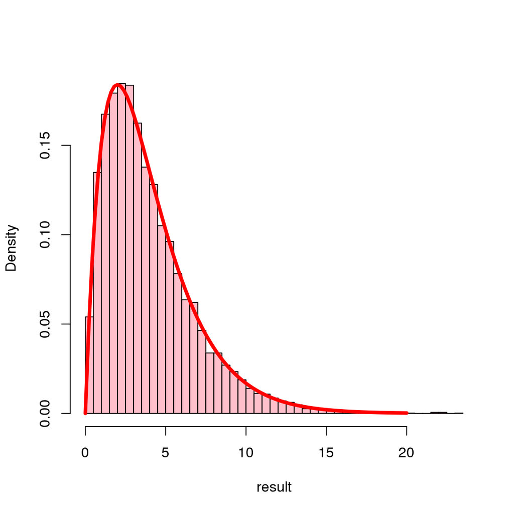

```r
# Or chisq.test(DPSC$SEX, DPSC$DEATHPEN)$p.value
hist(result, breaks = "Scott", col = "pink", freq=FALSE, main = "")
curve(dchisq(x, 4), 0, 20, add=TRUE, col = "red", lwd = 4)
### Using ggplot2 now
library(ggplot2)
```

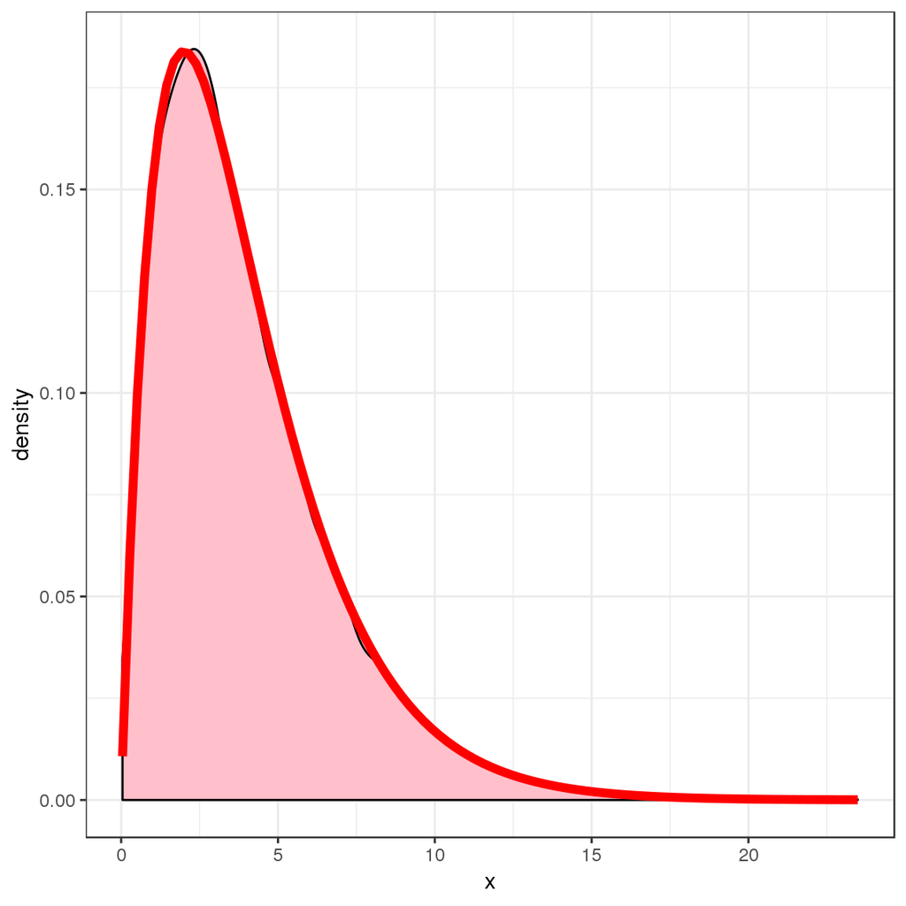

```r
DF <- data.frame(x = result)
p <- ggplot(data = DF, aes(x= x)) + geom_density(fill = "pink") + theme_bw()
p + stat_function(fun = dchisq, args = list(df = 4), color = "red", lwd = 2)
```

The simulated permutation $p$-value is 0.0096. The $p$-value that is returned from the `chisq.test()` is 0.0099664. In this case, the two $p$-values are fairly similar. This will not always be the case.

## Formatting the Data

Some times, you will have only access to data that has been summarized (contingency tables). To get your data into the needed format, you may want to use the following function written by [Marc Schwartz](https://stat.ethz.ch/pipermail/r-help/2006-October/115290.html) which will take a contingency table and convert it to a flat file. The function `expand.dft()` is also in the package `vcdExtra`.

```r
expand.dft <- function(x, na.strings = "NA", as.is = FALSE, dec = ".") {
    # Take each row in the source data frame table and replicate it
    # using the Freq value
    DF <- sapply(1:nrow(x),
                 function(i) x[rep(i, each = x$Freq[i]), ],
                 simplify = FALSE)

    # Take the above list and rbind it to create a single DF
    # Also subset the result to eliminate the Freq column
    DF <- subset(do.call("rbind", DF), select = -Freq)

    # Now apply type.convert to the character coerced factor columns
    # to facilitate data type selection for each column
    for (i in 1:ncol(DF)) {
        DF[[i]] <- type.convert(as.character(DF[[i]]),
                                na.strings = na.strings,
                                as.is = as.is, dec = dec)
    }

    DF
}
```

### Example Conversion

The `x=` argument to `expand.dft()` is a table that has been converted to a data frame. In the following example, a matrix of values is created that resembles a contingency table. To convert the matrix to a table, we use the function `as.table()`.To convert the table to a data frame, we use the function `as.data.frame()`. Finally, we apply the `expand.dft()` function to the contingency table that was converted to a data frame and stored in the object `HADF`.

```r
HA <- c(110, 277, 50, 163, 302, 63)
HAM <- matrix(data = HA, nrow = 2, byrow = TRUE)
dimnames(HAM) <- list(Gender = c("Male", "Female"), Giddy = c("Very Happy", "Pretty Happy", "Not to Happy"))
HAM
```

```
##         Giddy
## Gender   Very Happy Pretty Happy Not to Happy
##   Male          110          277           50
##   Female        163          302           63
```

```r
HAT <- as.table(HAM)
HAT
```

```
##         Giddy
## Gender   Very Happy Pretty Happy Not to Happy
##   Male          110          277           50
##   Female        163          302           63
```

```r
addmargins(HAT)
```

```
##         Giddy
## Gender   Very Happy Pretty Happy Not to Happy Sum
##   Male          110          277           50 437
##   Female        163          302           63 528
##   Sum           273          579          113 965
```

```r
HADF <- as.data.frame(HAT)
HATflatfile <- vcdExtra::expand.dft(HADF)
head(HATflatfile)
```

```
##   Gender      Giddy
## 1   Male Very Happy
## 2   Male Very Happy
## 3   Male Very Happy
## 4   Male Very Happy
## 5   Male Very Happy
## 6   Male Very Happy
```

```r
str(HATflatfile)
```

```
## 'data.frame':    965 obs. of  2 variables:
##  $ Gender: Factor w/ 2 levels "Female","Male": 2 2 2 2 2 2 2 2 2 2 ...
##  $ Giddy : Factor w/ 3 levels "Not to Happy",..: 3 3 3 3 3 3 3 3 3 3 ...
```

## Questions

From the http://sda.berkeley.edu/cgi-bin/hsda?harcsda+gss10 page, click Download > Customized Subset. Click in the radio button to the left of CSV file (Comma Separated Values with header record). Type `DEATHPEN DEGREE` in the Enter names of individual variables (original or created) to include box. Click in the radio button All for CASE IDENTIFICATION AND YEAR. Scroll to the bottom of the page, and click the Continue button. Review the page that appears to make sure you have selected the desired variables; then, click the `Create the Files` button. You should have two hot links: the `Data file` and the `Codebook`. By clicking on the `Data file` link, the information should open in your browser. To read the data into `R`, copy the url and store it as follows.

```r
# site <- "http://sda.berkeley.edu/TMPDIR/AAO0mzEh.csv"
# download.file(url = site, destfile = "../data/dpy.csv")
dpy <- read.csv(file = "../data/dpy.csv")
str(dpy)
```

```
## 'data.frame':    55087 obs. of  5 variables:
##  $ CASEID  : int  1 2 3 4 5 6 7 8 9 10 ...
##  $ DEATHPEN: int  0 0 0 0 0 0 0 0 0 0 ...
##  $ DEGREE  : int  3 0 1 3 1 1 1 3 1 1 ...
##  $ YEAR    : int  1972 1972 1972 1972 1972 1972 1972 1972 1972 1972 ...
##  $ ID      : int  1 2 3 4 5 6 7 8 9 10 ...
```

```r
xtabs(~DEATHPEN + DEGREE, data = dpy)
```

```
##         DEGREE
## DEATHPEN     0     1     2     3     4     8     9
##        0 12106 27564  2854  7450  3595    30   129
##        1   120   381    30    79    29     0     3
##        2    78   168    16    52    12     0     1
##        3    20    63     4    14     3     0     0
##        4    23    74     9    22     9     0     1
##        5    12    36     4    20    12     0     0
##        8    17    23     2    11     5     0     1
##        9     3     2     0     0     0     0     0
```

What is the only YEAR these two questions were asked?

There are several ways to answer this question, here is the first one that comes to mind.

```r
YQ <- subset(x = dpy, subset = DEATHPEN != 0 & DEGREE != 0)
head(YQ)
```

```
##       CASEID DEATHPEN DEGREE YEAR ID
## 26266  26266        1      1 1991  1
## 26267  26267        1      4 1991  2
## 26268  26268        2      4 1991  3
## 26269  26269        8      3 1991  4
## 26270  26270        1      1 1991  5
## 26273  26273        1      3 1991  8
```

```r
xtabs(~YEAR, data = YQ)
```

```
## YEAR
## 1991
## 1086
```

To satisfy the curious, the answer is 1991.

## Some code to answer Problem 10

```r
women <- c(35, 146)
men <- c(8, 97)
stuff <- rbind(women, men)
dimnames(stuff) <- list(Gender =c("Women", "Men"), Diet=c("Yes", "No"))
stuff
```

```
##        Diet
## Gender  Yes  No
##   Women  35 146
##   Men     8  97
```

```r
stuffT <- as.table(stuff)
stuffDF <- as.data.frame(stuffT)
head(stuffDF)
```

```
##   Gender Diet Freq
## 1  Women  Yes   35
## 2    Men  Yes    8
## 3  Women   No  146
## 4    Men   No   97
```

```r
DFL <- vcdExtra::expand.dft(stuffDF)
head(DFL)
```

```
##   Gender Diet
## 1  Women  Yes
## 2  Women  Yes
## 3  Women  Yes
## 4  Women  Yes
## 5  Women  Yes
## 6  Women  Yes
```

```r
set.seed(2)
N <- 10^4 - 1  # Change this for slower computers
result <- numeric(N)
for (i in 1:N) {
    T2 <- xtabs(~sample(Gender) + Diet, data = DFL)
    result[i] <- chisq.test(T2)$statistic
}
obs <- chisq.test(xtabs(~ Gender + Diet, data = DFL))$statistic
pvalue <- (sum(result >= obs) + 1)/(N + 1)
pvalue
```

```
## [1] 0.0092
```

## Test of Homogeneity

The major difference between testing for homogeneity and testing for independence is that you will have samples from two or more populations when testing for homogeneity. Recall that we only had one sample when we tested for independence. Consider testing whether the proportion of boys is the same as the proportions of girls that favor three different flavors of candy. That is, $H_0: \pi_{B1} = \pi_{G1}, \pi_{B2} = \pi_{G2}, \pi_{B3} =\pi_{G3}$ versus $H_A:$ at least one of the inequalities does not hold.

```r
candy <- c(42, 20, 38, 33, 27, 50)
candyM <- matrix(data = candy, nrow = 2, byrow = TRUE)
dimnames(candyM) <- list(Gender = c("Boys", "Girls"), Flavor = c("Flavor 1", "Flavor 2", "Flavor 3"))
candyM
```

```
##        Flavor
## Gender  Flavor 1 Flavor 2 Flavor 3
##   Boys        42       20       38
##   Girls       33       27       50
```

```r
candyT <- as.table(candyM)
candyT
```

```
##        Flavor
## Gender  Flavor 1 Flavor 2 Flavor 3
##   Boys        42       20       38
##   Girls       33       27       50
```

```r
addmargins(candyT)
```

```
##        Flavor
## Gender  Flavor 1 Flavor 2 Flavor 3 Sum
##   Boys        42       20       38 100
##   Girls       33       27       50 110
##   Sum         75       47       88 210
```

```r
candyDF <- as.data.frame(candyT)
candyflatfile <- vcdExtra::expand.dft(candyDF)
head(candyflatfile)
```

```
##   Gender   Flavor
## 1   Boys Flavor 1
## 2   Boys Flavor 1
## 3   Boys Flavor 1
## 4   Boys Flavor 1
## 5   Boys Flavor 1
## 6   Boys Flavor 1
```

```r
str(candyflatfile)
```

```
## 'data.frame':    210 obs. of  2 variables:
##  $ Gender: Factor w/ 2 levels "Boys","Girls": 1 1 1 1 1 1 1 1 1 1 ...
##  $ Flavor: Factor w/ 3 levels "Flavor 1","Flavor 2",..: 1 1 1 1 1 1 1 1 1 1 ...
```

```r
E <- chisq.test(candyT)$expected
E
```

```
##        Flavor
## Gender  Flavor 1 Flavor 2 Flavor 3
##   Boys  35.71429 22.38095 41.90476
##   Girls 39.28571 24.61905 46.09524
```

```r
obsstat <- chisq.test(candyT)$statistic
obsstat
```

```
## X-squared
##  3.290187
```

```r
# Now we will run a permutation test.
N <- 10^4 - 1  # Change this for slower computers
result <- numeric(N)
set.seed(1)
for (i in 1:N) {
    T2 <- xtabs(~sample(Gender) + Flavor, data = candyflatfile)
    result[i] <- chisq.test(T2)$statistic
}
pvalue <- (sum(result >= obsstat) + 1)/(N + 1)
pvalue
```

```
## [1] 0.1941
```

In this case, there is no evidence to suggest the proportions of boys favoring flavors one, two, and three is any different than the proportions of girls favoring flavors one, two and three.

## Goodness of Fit

A quality engineer has taken 50 samples of size 13 each from a production process. The numbers of defectives for these samples are given in the code. Test the null hypothesis at an $\alpha =0.05$ level that the number of defective follows (a) the Poisson distribution, (b) the binomial distribution.

```r
numberDefectives <- c(0,1,2,3,4,5,"6 or more")
numberSamples <- c(10, 24, 10, 4, 1, 1, 0)
names(numberSamples) <- numberDefectives
numberSamples
```

```
##         0         1         2         3         4         5 6 or more
##        10        24        10         4         1         1         0
```

Since no parameters are specified, they must be estimated from the data in order to carry out the test in both (a) and (b).

See dist.pdf for a summary of various probability distributions. The Poisson pdf is $P(X =x|\lambda) = \frac{\lambda e^{-\lambda}}{x!}$ with $E[X] =\lambda$. And estimate of the mean number of defectives in the 50 samples is 1.3.

```r
muest <- sum(numberSamples[-7]*c(0,1,2,3,4,5))/50
muest
```

```
## [1] 1.3
```

Using $\hat{\lambda} = 1.3$, we compute the probabilities for each category and subsequent expected values.

```r
ps <- dpois(0:4, muest)
p5m <- 1 - ppois(4, muest)
psf <- c(ps, p5m)
psf
```

```
## [1] 0.27253179 0.35429133 0.23028937 0.09979206 0.03243242 0.01066303
```

```r
exh <- psf*50
exh
```

```
## [1] 13.6265897 17.7145665 11.5144683  4.9896029  1.6216209  0.5331517
```

```r
((numberSamples[-7] - exh)^2/exh)
```

```
##         0         1         2         3         4         5
## 0.9651830 2.2301801 0.1991941 0.1962709 0.2382879 0.4087905
```

```r
stat <- sum((numberSamples[-7] - exh)^2/exh)
stat
```

```
## [1] 4.237906
```

```r
epvalue <- pchisq(stat, 6-1-1, lower=FALSE)
epvalue
```

```
## [1] 0.3747651
```

Since the $p$-value is 0.3747651, we can not reject the null hypothesis that the distribution follows a Poisson distribution. That is, there is no evidence to suggest the distribution is something other than the Poisson distribution.

One really needs the expected cell counts to be at least five. Consider collapsing the number of defectives greater than or equal to 3 to a single category.

```r
ps <- dpois(0:2, muest)
p3m <- 1 - ppois(2, muest)
psf <- c(ps, p3m)
psf
```

```
## [1] 0.2725318 0.3542913 0.2302894 0.1428875
```

```r
exh <- psf*50
exh
```

```
## [1] 13.626590 17.714567 11.514468  7.144376
```

```r
((numberSamples[-c(7,6,5)] + c(0,0,0,2) - exh)^2/exh)
```

```
##         0         1         2         3
## 0.9651830 2.2301801 0.1991941 0.1833044
```

```r
stat <- sum((numberSamples[-c(7,6,5)] + c(0,0,0,2) - exh)^2/exh)
stat
```

```
## [1] 3.577862
```

```r
epvalue2 <- pchisq(stat, 4-1-1, lower=FALSE)
epvalue2
```

```
## [1] 0.1671388
```

```r
# Could use the following but the degrees of freedom will be incorrect for this test!
chisq.test(c(10, 24, 10, 6), p=psf)
```

```
##
##  Chi-squared test for given probabilities
##
## data:  c(10, 24, 10, 6)
## X-squared = 3.5779, df = 3, p-value = 0.3108
```

Note the substantial drop in $p$-value (0.1671388) although the final conclusion is still the same.

For part (b), the null hypothesis is that the number of defectives in each sample of 13 follows the binomial distribution with $n = 13$ and $\pi$ equal the probability of a defective in any sample. An estimate of $\pi$, $\hat{\pi}$ is the total number of defectives (65) divided by the total number of observations (650). That is $\hat{\pi} = 0.1$.

```r
pihat <- 65/650
ps <- dbinom(0:2, 13, pihat)
p3m <- 1 - pbinom(2, 13, pihat)
psf <- c(ps, p3m)
psf
```

```
## [1] 0.2541866 0.3671584 0.2447723 0.1338828
```

```r
exh <- psf*50
exh
```

```
## [1] 12.709329 18.357920 12.238613  6.694138
```

```r
((numberSamples[-c(7,6,5)] + c(0,0,0,2) - exh)^2/exh)
```

```
##          0          1          2          3
## 0.57756506 1.73402370 0.40947362 0.07197749
```

```r
stat <- sum((numberSamples[-c(7,6,5)] + c(0,0,0,2)  - exh)^2/exh)
stat
```

```
## [1] 2.79304
```

```r
epvalue3 <- pchisq(stat, 4-1-1, lower=FALSE)
epvalue3
```

```
## [1] 0.2474566
```

This example illustrates a common result with chi-square goodness-of-fit tests, i.e., that each to two (or more) different null hypotheses may be accepted for the same data set. Obviously, the true distribution cannot be both binomial and Poisson at the same time which is why the conclusion is that there is not sufficient evidence to suggest the alternative. This does not make the null hypothesis true!